# Activity2-NFL

Canberraangel

22 March 2019

**General Comments** I found this activity somewhat confusing. I found it hard to recall which objects contained which data. A couple of times after I had pre-processed the data, I found the objects still had NA’s which had to be processed again. I think this was because I included the case number and player names in the initial objects then had to remove them and create new objects.

```r
setwd("C:/Users/canbe/OneDrive/Documents/JEANS/University/Informatics")
getwd()
```

```
## [1] "C:/Users/canbe/OneDrive/Documents/JEANS/University/Informatics"
```

```r
nfl=read.csv("nfl_data.csv")
head(nfl)
```

```
##   case_no                   Player Year Age  Tm  G GS Cmp Att  Yds Int Sk
## 1       1 Peyton Manning\\MannPe00 2013  37 DEN 16 16 450 659 5477  10 18
## 2       2      Tom Brady\\BradTo00 2007  30 NWE 16 16 398 578 4806   8 21
## 3       3 Peyton Manning\\MannPe00 2004  28 IND 16 16 336 497 4557  10 13
## 4       4     Drew Brees\\BreeDr00 2011  32 NOR 16 16 468 657 5476  14 24
## 5       5  Aaron Rodgers\\RodgAa00 2011  28 GNB 15 15 343 502 4643   6 36
## 6       6     Drew Brees\\BreeDr00 2012  33 NOR 16 16 422 670 5177  19 26
##   TD
## 1 55
## 2 50
## 3 49
## 4 46
## 5 45
## 6 43
```

## Upload the data for the activity

```r
grep("Cmp", colnames(nfl))
```

```
## [1] 8
```

```r
grep("Att", colnames(nfl))
```

```
## [1] 9
```

```r
grep("Yds", colnames(nfl))
```

```
## [1] 10
```

```r
grep("Int", colnames(nfl))
```

```
## [1] 11
```

```r
grep("Sk", colnames(nfl))
```

```
## [1] 12
```

```r
grep("TD", colnames(nfl))
```

```
## [1] 13
```

## Identify the column numbers so that I can create an object with the columns I want.

```r
nfl2=nfl[c(1,2,8:13)]
head(nfl2)
```

```
##   case_no                   Player Cmp Att  Yds Int Sk TD
## 1       1 Peyton Manning\\MannPe00 450 659 5477  10 18 55
## 2       2      Tom Brady\\BradTo00 398 578 4806   8 21 50
## 3       3 Peyton Manning\\MannPe00 336 497 4557  10 13 49
## 4       4     Drew Brees\\BreeDr00 468 657 5476  14 24 46
## 5       5  Aaron Rodgers\\RodgAa00 343 502 4643   6 36 45
## 6       6     Drew Brees\\BreeDr00 422 670 5177  19 26 43
```

## Create the new object with only the columns I need

```r
library(caret)
set.seed(1)
sample=createDataPartition(y=nfl2$TD, p=0.75, list=FALSE)
train=nfl2[sample,]
test=nfl2[-sample,]
dim(train)
```

```
## [1] 577   8
```

```r
dim(test)
```

```
## [1] 191   8
```

## Create training set and test set of data. Check dimensions.

```r
sum(is.na(train))
```

```
## [1] 3
```

```r
which(is.na(train), arr.ind = TRUE)
```

```
##    row col
## 16  12   3
## 32  21   6
## 9    6   7
```

## Question 3: Now many NAs in the training dataset?

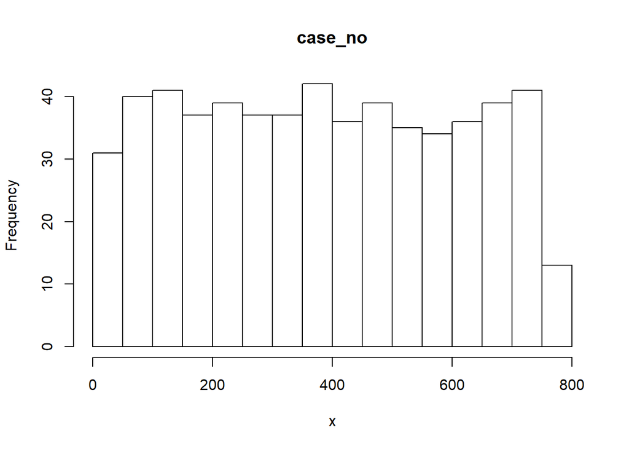

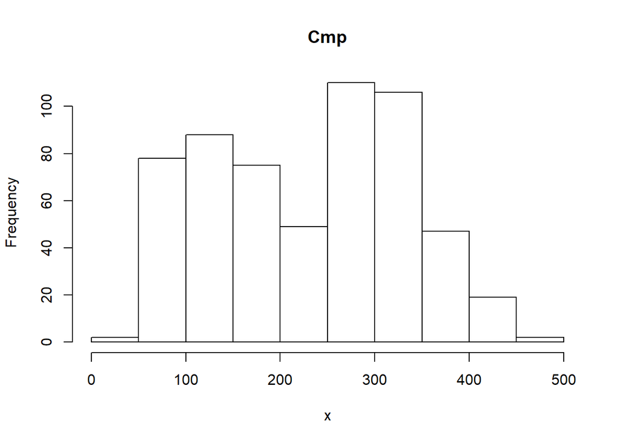

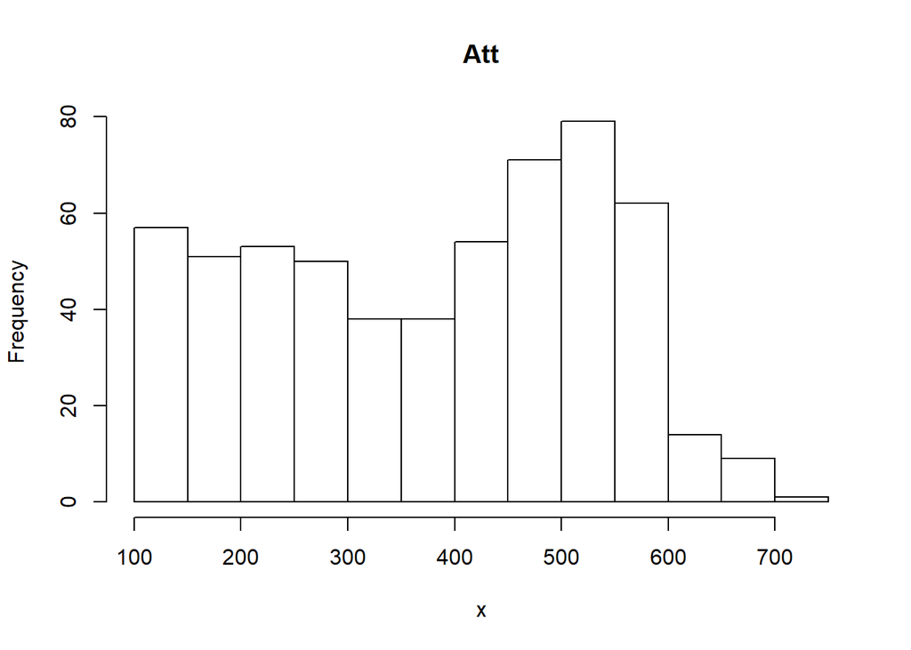

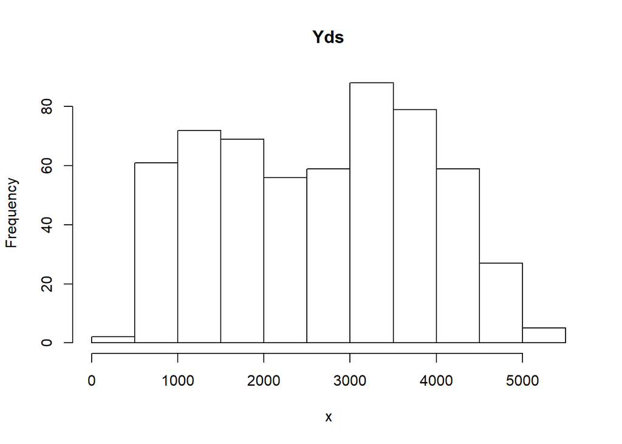

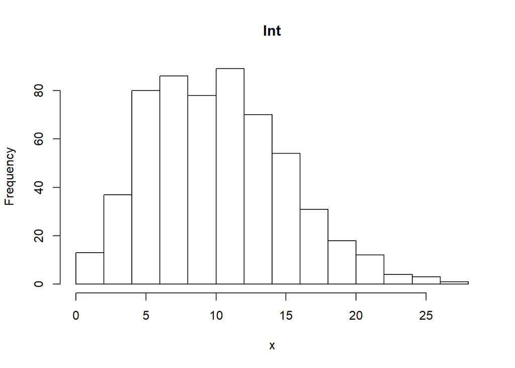

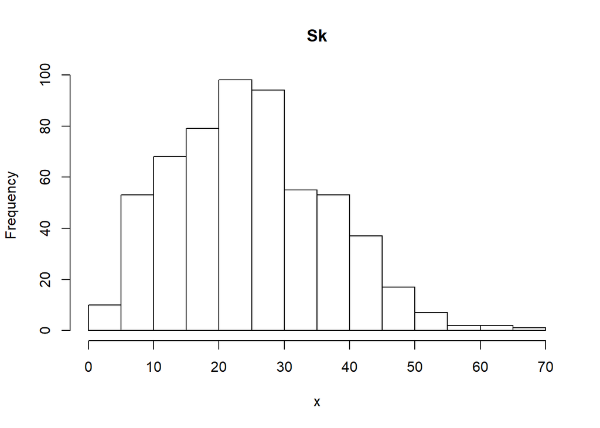

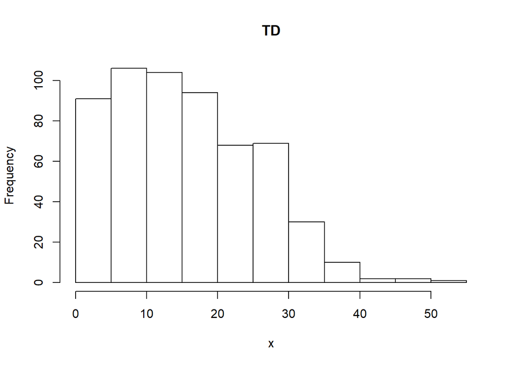

```r
train=as.data.frame(train)
nums=which(unlist(lapply(train, is.numeric)))
for (i in nums) {
x=train[,i]
var.names=names(train)[i]
hist(x, main= var.names)
}
```

```r
grep("TD", colnames(nfl))
```

```
## [1] 13
```

## Create histograms of each variable to check normality of data. (Disregard Case Number)

```r
library(RANN)
prepImp=preProcess(nfl2[-13],method="knnImpute")
train_processed=predict(prepImp, train)
```

```r
unPreProc <- function(preProc, data){
  stopifnot(class(preProc) == "preProcess")
  stopifnot(class(data) == "data.frame")
  for(i in names(preProc$mean)){
    tmp <- data[, i] * preProc$std[[i]] + preProc$mean[[i]]
    data[, i] <- tmp
  }
  return(data)
}
```

```r
sum(is.na(train_processed))
```

```
## [1] 0
```

```r
train_processed=unPreProc(prepImp, train_processed)
str(train_processed)
```

```
## 'data.frame':    577 obs. of  8 variables:
##  $ case_no: num  1 3 4 5 7 9 10 11 13 14 ...
##  $ Player : Factor w/ 195 levels "A.J. Feeley\\FeelA.00",..: 141 141 70 4 134 4 178 70 141 4 ...
##  $ Cmp    : num  450 336 468 343 421 401 401 446 395 371 ...
##  $ Att    : num  659 497 657 502 663 610 611 650 597 552 ...
##  $ Yds    : num  5477 4557 5476 4643 5038 ...
##  $ Int    : num  10 10 14 6 16 7 12 12 15 8 ...
##  $ Sk     : num  18 13 24 36 36 31.6 32 37 17 51 ...
##  $ TD     : num  55 49 46 45 41 40 39 39 39 39 ...
```

## Impute missing values in training dataset (K nearest neighbour method). Un-pre process to unstandardise the data set.

```r
nzv=nearZeroVar(train_processed)
nzv
```

```
## integer(0)
```

```r
sum(is.na(test))
```

```
## [1] 4
```

```r
which(is.na(test), arr.ind = TRUE)
```

```
##    row col
## 38  14   4
## 23   8   5
## 23   8   6
## 45  16   7
```

```r
test_processed=predict(prepImp, test)
```

```r
prepImp1=preProcess(test[,-13],method="knnImpute")
test_processed=predict(prepImp1,test)
sum(is.na(test_processed))
```

```
## [1] 0
```

```r
test_processed=unPreProc(prepImp, test_processed)
str(test_processed)
```

```
## 'data.frame':    191 obs. of  8 variables:
##  $ case_no: num  6.62 10.59 12.58 16.56 21.53 ...
##  $ Player : Factor w/ 195 levels "A.J. Feeley\\FeelA.00",..: 178 70 8 58 70 178 178 16 73 70 ...
##  $ Cmp    : num  394 417 376 375 465 ...
##  $ Att    : num  572 661 609 543 664 ...
##  $ Yds    : num  4770 5136 4726 4683 5166 ...
##  $ Int    : num  8.22 18.43 15.65 11.01 14.72 ...
##  $ Sk     : num  21.1 26.1 27.1 46.3 27.1 ...
##  $ TD     : num  48.8 42 39.1 38.2 36.2 ...
```

## Perform pre-processing on test data set then un-standardise the data.

```r
newTrain=train
newTrain$Int_perAtt=newTrain$Int/newTrain$Att
newTrain$Cmp_perAtt=newTrain$Cmp/newTrain$Att
newTrain$Sk_perAtt=newTrain$Sk/newTrain$Att
newTrain$Yds_perAtt=newTrain$Yds/newTrain$Att

newTest=test
newTest$Int_perAtt=newTest$Int/newTest$Att
newTest$Cmp_perAtt=newTest$Cmp/newTest$Att
newTest$Sk_perAtt=newTest$Sk/newTest$Att
newTest$Yds_perAtt=newTest$Yds/newTest$Att
```

## create new variables and place in new object ‘newTrain’

```r
grep("Int_perAtt", colnames(newTrain))
```

```
## [1] 9
```

```r
grep("Cmp_perAtt", colnames(newTrain))
```

```
## [1] 10
```

```r
grep("Sk_perAtt", colnames(newTrain))
```

```
## [1] 11
```

```r
grep("Yds_perAtt", colnames(newTrain))
```

```
## [1] 12
```

```r
grep("TD", colnames(newTrain))
```

```
## [1] 8
```

## Identify column numbers to create new object with only those variables.

```r
newTrain=newTrain[c(1,2,8:12)]
head(newTrain)
```

```
##   case_no                     Player TD Int_perAtt Cmp_perAtt  Sk_perAtt
## 1       1   Peyton Manning\\MannPe00 55 0.01517451  0.6828528 0.02731411
## 3       3   Peyton Manning\\MannPe00 49 0.02012072  0.6760563 0.02615694
## 4       4       Drew Brees\\BreeDr00 46 0.02130898  0.7123288 0.03652968
## 5       5    Aaron Rodgers\\RodgAa00 45 0.01195219  0.6832669 0.07171315
## 7       7 Matthew Stafford\\StafMa00 41 0.02413273  0.6349925 0.05429864
## 9       9    Aaron Rodgers\\RodgAa00 40 0.01147541  0.6573770         NA
##   Yds_perAtt
## 1   8.311077
## 3   9.169014
## 4   8.334855
## 5   9.249004
## 7   7.598793
## 9   7.259016
```

```r
newTest=newTest[c(1,2,8:12)]
head(newTest)
```

```
##    case_no                     Player TD Int_perAtt Cmp_perAtt  Sk_perAtt
## 2        2        Tom Brady\\BradTo00 50 0.01384083  0.6885813 0.03633218
## 6        6       Drew Brees\\BreeDr00 43 0.02835821  0.6298507 0.03880597
## 8        8      Andrew Luck\\LuckAn00 40 0.02597403  0.6168831 0.04383117
## 12      12 Daunte Culpepper\\CulpDa00 39 0.02007299  0.6916058 0.08394161
## 17      17       Drew Brees\\BreeDr00 37 0.02228826  0.6998514 0.04011887
## 19      19        Tom Brady\\BradTo00 36 0.01121795  0.6442308 0.06089744
##    Yds_perAtt
## 2    8.314879
## 6    7.726866
## 8    7.728896
## 12   8.607664
## 17   7.738484
## 19   7.644231
```

```r
newTrain2=newTrain[c(3:7)]
```

## Removed case number and Player from the dataset and saved to a new object ‘newTrain2’

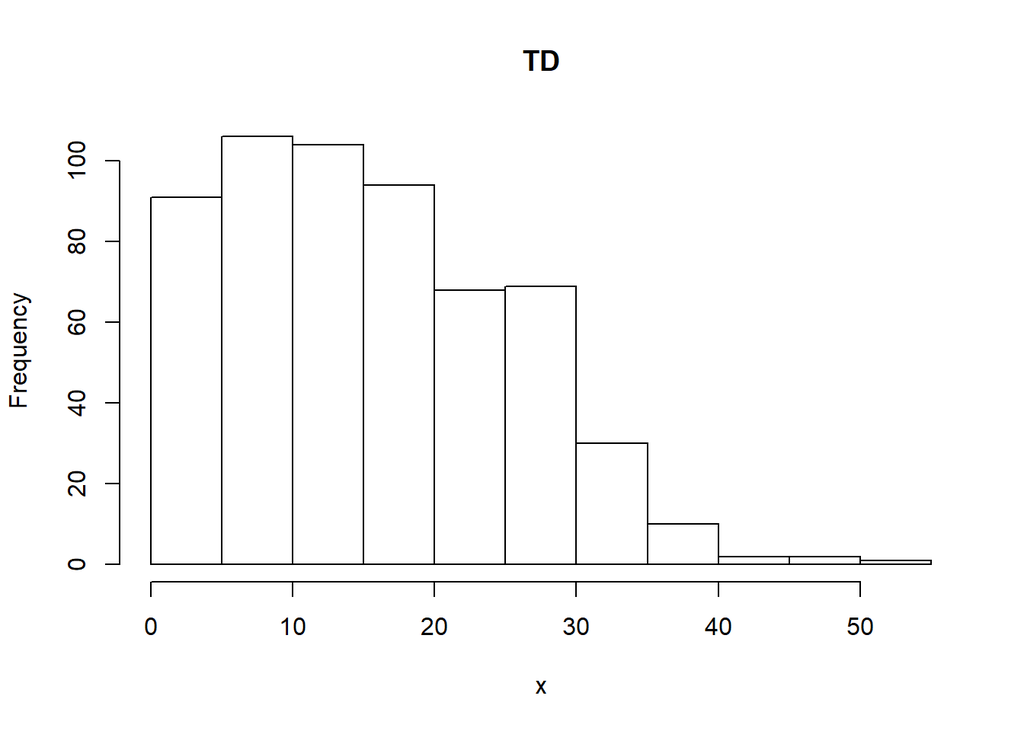

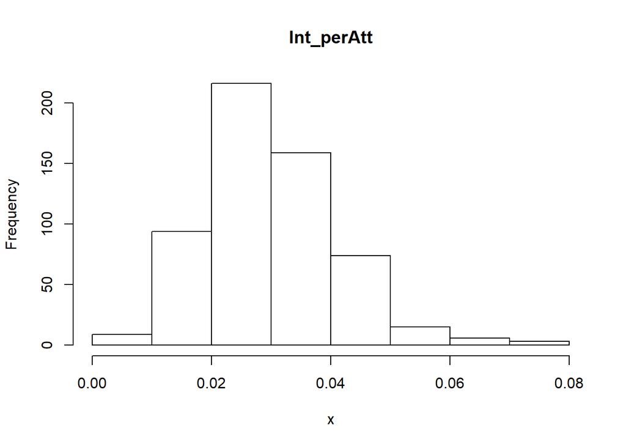

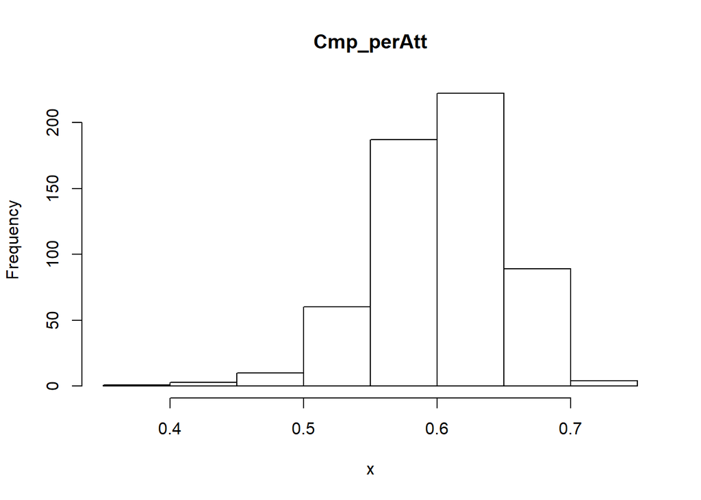

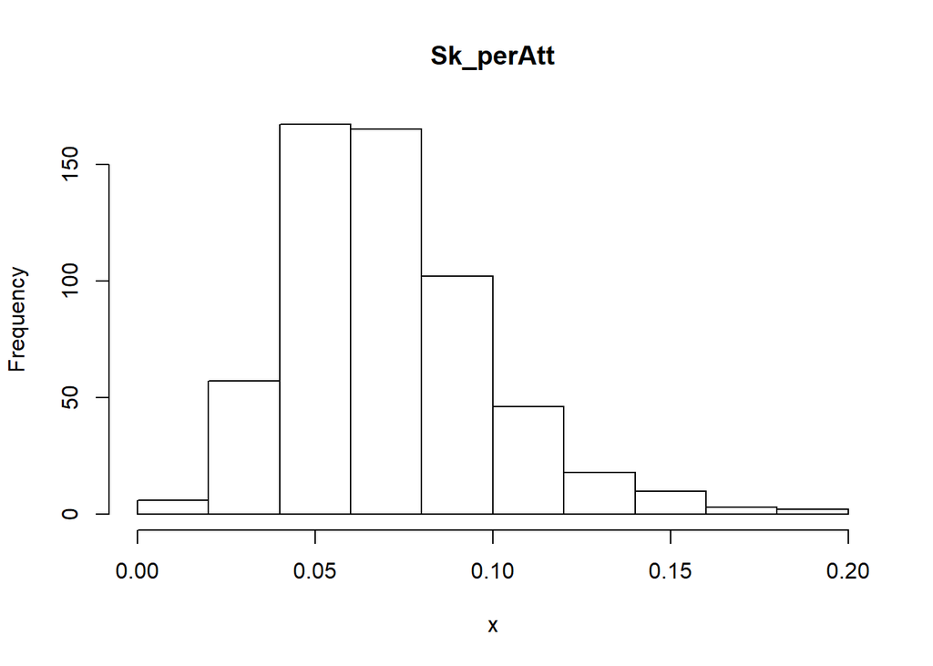

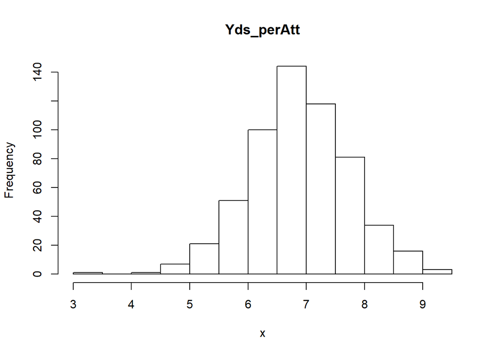

```r
newTrain2=as.data.frame(newTrain2)
nums=which(unlist(lapply(newTrain2, is.numeric)))
for (i in nums) {
x=newTrain2 [,i]
var.names=names(newTrain2)[i]
hist(x,main = var.names)
}
```

##QUESTION 3: Created histograms for each of the new variables to identify skewness.

```r
newTrain$TD_perAtt=newTrain$TD/train$Att
head(newTrain)
```

```
##   case_no                     Player TD Int_perAtt Cmp_perAtt  Sk_perAtt
## 1       1   Peyton Manning\\MannPe00 55 0.01517451  0.6828528 0.02731411
## 3       3   Peyton Manning\\MannPe00 49 0.02012072  0.6760563 0.02615694
## 4       4       Drew Brees\\BreeDr00 46 0.02130898  0.7123288 0.03652968
## 5       5    Aaron Rodgers\\RodgAa00 45 0.01195219  0.6832669 0.07171315
## 7       7 Matthew Stafford\\StafMa00 41 0.02413273  0.6349925 0.05429864
## 9       9    Aaron Rodgers\\RodgAa00 40 0.01147541  0.6573770         NA
##   Yds_perAtt  TD_perAtt
## 1   8.311077 0.08345979
## 3   9.169014 0.09859155
## 4   8.334855 0.07001522
## 5   9.249004 0.08964143
## 7   7.598793 0.06184012
## 9   7.259016 0.06557377
```

```r
newTest$TD_perAtt=newTest$TD/test$Att
```

## Forgot to create variable TD_perATT. Now created and added to the object.

```r
nzv=nearZeroVar(train_processed[,-3])
nzv
```

```
## integer(0)
```

## QUESTION 5: Identify variables with near zero variance

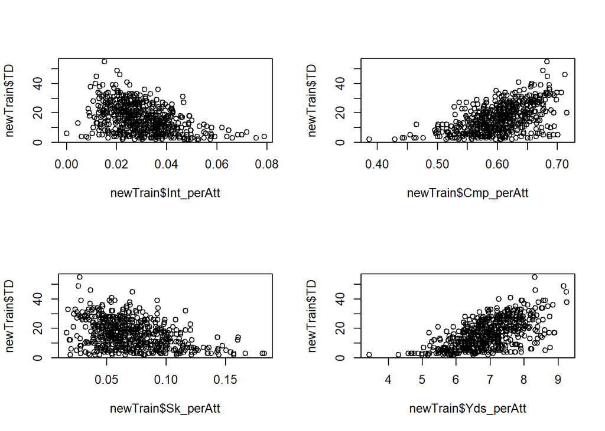

```r
par(mfrow=c(2,2))
plot(newTrain$Int_perAtt, newTrain$TD)
plot(newTrain$Cmp_perAtt, newTrain$TD)
plot(newTrain$Sk_perAtt, newTrain$TD)
plot(newTrain$Yds_perAtt, newTrain$TD)
```

##QUESTION 6: Create single plot to show relationship response variable to all other variables.

```r
head(newTrain)
```

```
##   case_no                     Player TD Int_perAtt Cmp_perAtt  Sk_perAtt
## 1       1   Peyton Manning\\MannPe00 55 0.01517451  0.6828528 0.02731411
## 3       3   Peyton Manning\\MannPe00 49 0.02012072  0.6760563 0.02615694
## 4       4       Drew Brees\\BreeDr00 46 0.02130898  0.7123288 0.03652968
## 5       5    Aaron Rodgers\\RodgAa00 45 0.01195219  0.6832669 0.07171315
## 7       7 Matthew Stafford\\StafMa00 41 0.02413273  0.6349925 0.05429864
## 9       9    Aaron Rodgers\\RodgAa00 40 0.01147541  0.6573770         NA
##   Yds_perAtt  TD_perAtt
## 1   8.311077 0.08345979
## 3   9.169014 0.09859155
## 4   8.334855 0.07001522
## 5   9.249004 0.08964143
## 7   7.598793 0.06184012
## 9   7.259016 0.06557377
```

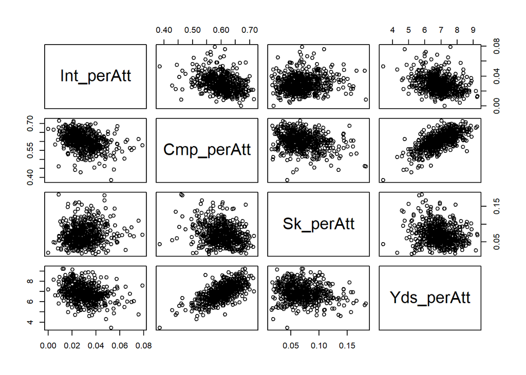

```r
plot(newTrain[,4:7])
```

##QUESTION 8: Create single plot to show relationship between features without response variable.

```r
newTrain3=newTrain[c(4:7)]
corMat=cor(newTrain3)
highlyCorNames=findCorrelation(corMat, cutoff=0.7, names=TRUE)
highlyCorNames
```

```
## character(0)
```

## QUESTION 10: Is there evidence of multicollinearity?

```r
newTrain3=newTrain[c(4:8)]
head(newTrain3)
```

```
##   Int_perAtt Cmp_perAtt  Sk_perAtt Yds_perAtt  TD_perAtt
## 1 0.01517451  0.6828528 0.02731411   8.311077 0.08345979
## 3 0.02012072  0.6760563 0.02615694   9.169014 0.09859155
## 4 0.02130898  0.7123288 0.03652968   8.334855 0.07001522
## 5 0.01195219  0.6832669 0.07171315   9.249004 0.08964143
## 7 0.02413273  0.6349925 0.05429864   7.598793 0.06184012
## 9 0.01147541  0.6573770         NA   7.259016 0.06557377
```

```r
?findCorrelation
```

```
## starting httpd help server ... done
```

findCorrelation(x, cutoff = 0.9, verbose = FALSE, names = FALSE, exact = ncol(x) < 100)

```r
sum(is.na(newTrain3))
```

```
## [1] 3
```

```r
prepImp4=preProcess(newTrain3,method="knnImpute")
train_processed5=predict(prepImp4, newTrain3)
```

## Impute missing values in new training dataset

```r
train_processed5=unPreProc(prepImp4, train_processed5)
```

## Unstandardised pre-processed training dataset

```r
corMat=cor(train_processed5)
highlyCorNames=findCorrelation(corMat, cutoff=0.6, names=TRUE)
highlyCorNames
```

```
## [1] "Yds_perAtt"
```

## Quetion 10: Yds_perAtt is multicollinear.

## I had to re-process the data as I kept getting an error. I don’t understand how I managed to get NAs in the data.

```r
highlyCor=findCorrelation(corMat, cutoff=0.6)
highlyCor
```

```
## [1] 4
```

## Find which column is highy correlated so that it can be removed.

```r
train_processed5=train_processed5[,-highlyCor]
head(train_processed5)
```

```
##   Int_perAtt Cmp_perAtt  Sk_perAtt  TD_perAtt
## 1 0.01517451  0.6828528 0.02731411 0.08345979
## 3 0.02012072  0.6760563 0.02615694 0.09859155
## 4 0.02130898  0.7123288 0.03652968 0.07001522
## 5 0.01195219  0.6832669 0.07171315 0.08964143
## 7 0.02413273  0.6349925 0.05429864 0.06184012
## 9 0.01147541  0.6573770 0.05995654 0.06557377
```

## Removed feature “Yds_perAtt” from the object

## QUESTION 11: Create a repeated cross-validation with 5 samples and 10 repeats to predict touchdowns. Which features have a significant effect?

```r
head(train_processed5)
```

```
##   Int_perAtt Cmp_perAtt  Sk_perAtt  TD_perAtt
## 1 0.01517451  0.6828528 0.02731411 0.08345979
## 3 0.02012072  0.6760563 0.02615694 0.09859155
## 4 0.02130898  0.7123288 0.03652968 0.07001522
## 5 0.01195219  0.6832669 0.07171315 0.08964143
## 7 0.02413273  0.6349925 0.05429864 0.06184012
## 9 0.01147541  0.6573770 0.05995654 0.06557377
```

newTrain4=as.data.frame(c(newTrain$TD,train_processed5)) head(newTrain4)

```r
fitControl=trainControl(method="repeatedcv", number = 5, repeats = 10)
```

train_processed5$TD=newTrain$TD

```r
train_processed5$TD=newTrain$TD
train_processed6=train_processed5[,-5]
head(train_processed6)
```

```
##   Int_perAtt Cmp_perAtt  Sk_perAtt  TD_perAtt
## 1 0.01517451  0.6828528 0.02731411 0.08345979
## 3 0.02012072  0.6760563 0.02615694 0.09859155
## 4 0.02130898  0.7123288 0.03652968 0.07001522
## 5 0.01195219  0.6832669 0.07171315 0.08964143
## 7 0.02413273  0.6349925 0.05429864 0.06184012
## 9 0.01147541  0.6573770 0.05995654 0.06557377
```

## Added TD back in to object train_processed5

```r
set.seed(3)
TDs_mdl=train(TD ~ ., data=train_processed5, method="lm", trControl=fitControl)
summary(TDs_mdl)
```

```
##
## Call:
## lm(formula = .outcome ~ ., data = dat)
##
## Residuals:
##     Min      1Q  Median      3Q     Max
## -23.517  -3.360   0.871   4.015  13.922
##
## Coefficients:
##             Estimate Std. Error t value Pr(>|t|)
## (Intercept)  -11.406      3.666  -3.111  0.00196 **
## Int_perAtt  -125.767     22.077  -5.697 1.96e-08 ***
## Cmp_perAtt    28.691      5.805   4.943 1.01e-06 ***
## Sk_perAtt    -49.983      8.715  -5.735 1.58e-08 ***
## TD_perAtt    433.328     20.515  21.122  < 2e-16 ***
## ---
## Signif. codes:  0 '***' 0.001 '**' 0.01 '*' 0.05 '.' 0.1 ' ' 1
##
## Residual standard error: 5.628 on 572 degrees of freedom
## Multiple R-squared:  0.6573, Adjusted R-squared:  0.6549
## F-statistic: 274.3 on 4 and 572 DF,  p-value: < 2.2e-16
```

```r
TDs_mdl
```

```
## Linear Regression
##
## 577 samples
##   4 predictor
##
## No pre-processing
## Resampling: Cross-Validated (5 fold, repeated 10 times)
## Summary of sample sizes: 461, 461, 462, 462, 462, 462, ...
## Resampling results:
##
##   RMSE      Rsquared  MAE
##   5.646319  0.652868  4.452343
##
## Tuning parameter 'intercept' was held constant at a value of TRUE
```

## Question 12:

## Check the lecture notes to see if RMSE is correct

```r
newTrain5=newTrain3
newTrain5$TD=newTrain$TD
```

```r
sum(is.na(newTrain5))
```

```
## [1] 3
```

```r
prepImp6=preProcess(newTrain5,method="knnImpute")
train_processed6=predict(prepImp4, newTrain5)
train_processed6=unPreProc(prepImp4, train_processed6)
sum(is.na(train_processed6))
```

```
## [1] 0
```

## Must have been wrong in earlier question as removed Yards from model. Try it with earlier object which includes Yards

```r
set.seed(3)
TDs_mdl1=train(TD ~ ., train_processed6, method= "lm", trControl=fitControl)
summary(TDs_mdl1)
```

```
##
## Call:
## lm(formula = .outcome ~ ., data = dat)
##
## Residuals:
##      Min       1Q   Median       3Q      Max
## -23.4920  -3.3581   0.8863   4.0149  13.9488
##
## Coefficients:
##               Estimate Std. Error t value Pr(>|t|)
## (Intercept)  -11.45649    3.69480  -3.101  0.00203 **
## Int_perAtt  -125.61408   22.13519  -5.675 2.21e-08 ***
## Cmp_perAtt    28.27693    6.80903   4.153 3.79e-05 ***
## Sk_perAtt    -50.09637    8.77654  -5.708 1.84e-08 ***
## Yds_perAtt     0.05374    0.46102   0.117  0.90724
## TD_perAtt    431.66258   25.01606  17.255  < 2e-16 ***
## ---
## Signif. codes:  0 '***' 0.001 '**' 0.01 '*' 0.05 '.' 0.1 ' ' 1
##
## Residual standard error: 5.633 on 571 degrees of freedom
## Multiple R-squared:  0.6573, Adjusted R-squared:  0.6543
## F-statistic:   219 on 5 and 571 DF,  p-value: < 2.2e-16
```

## QUESTION 13, 14

## Here is the model after I added Yards back in.

```r
TDs_mdl1
```

```
## Linear Regression
##
## 577 samples
##   5 predictor
##
## No pre-processing
## Resampling: Cross-Validated (5 fold, repeated 10 times)
## Summary of sample sizes: 461, 461, 462, 462, 462, 462, ...
## Resampling results:
##
##   RMSE      Rsquared   MAE
##   5.658056  0.6514821  4.460104
##
## Tuning parameter 'intercept' was held constant at a value of TRUE
```

## QUESTION 15: RMSE

## Again, after yards added back in.

```r
sum(is.na(newTest))
```

```
## [1] 8
```

```r
prepImpTest=preProcess(newTest,method="knnImpute")
test_processed1=predict(prepImpTest, newTest)
sum(is.na(test_processed1))
```

```
## [1] 0
```

```r
test_processed1=unPreProc(prepImpTest, test_processed1)
```

```r
predicted_TDs=predict(TDs_mdl1, newdata = test_processed1)
head(predicted_TDs)
```

```
##        2        6        8       12       17       19
## 42.24368 28.96651 28.97400 32.55650 27.67134 27.61494
```

## QUESTION 19: Model performance

```r
data.frame(observed_TDs = test_processed1$TD, predicted_TDs)
```

```
##     observed_TDs predicted_TDs
## 2             50    42.2436840
## 6             43    28.9665114
## 8             40    28.9739984
## 12            39    32.5564952
## 17            37    27.6713419
## 19            36    27.6149416
## 20            36    35.6091832
## 23            35    22.7897515
## 24            35    26.0489357
## 28            34    26.0878124
## 30            34    32.6443935
## 34            33    27.8098547
## 37            33    28.9266293
## 38            33    27.5960590
```

[output cut: 177 more lines]

```r
OP=data.frame(observed_TDs = test_processed1$TD, predicted_TDs)
```

```r
OP$diff=OP$observed_TDs-OP$predicted_TDs
mean(OP$diff)
```

```
## [1] -0.2148662
```

```r
mean(OP$observed_TDs)
```

```
## [1] 16.27225
```

## Question 19: Work out difference between observed and predicted.

# QUESTION 17/18: Out-of-sample RMSE

```r
postResample(pred=predicted_TDs, obs = test_processed1$TD)
```

```
##      RMSE  Rsquared       MAE
## 6.4417721 0.5803154 4.9971722
```